# lab6

Author

Nicole Tang

# Learning goals

- Use `unnest_tokens()` and `unnest_ngrams()` to extract tokens and ngrams from text.
- Use dplyr and ggplot2 to analyze text data

# Lab description

For this lab we will be working with a new dataset. The dataset contains transcription samples from https://www.mtsamples.com/. And is loaded and “fairly” cleaned at https://raw.githubusercontent.com/USCbiostats/data-science-data/master/00_mtsamples/mtsamples.csv.

### read in Medical Transcriptions

Loading in reference transcription samples from https://www.mtsamples.com/

```r
library(readr)
library(dplyr)
mt_samples <- read_csv("https://raw.githubusercontent.com/USCbiostats/data-science-data/master/00_mtsamples/mtsamples.csv")
```

```
──────────────────────────────────────────────────────── Delimiter: "," chr
(5): description, medical_specialty, sample_name, transcription, keywords dbl
(1): ...1
```

```r
mt_samples <- mt_samples %>%
  select(description, medical_specialty, transcription)

head(mt_samples)
```

```
# A tibble: 6 × 3
  description                                    medical_specialty transcription
  <chr>                                          <chr>             <chr>
1 A 23-year-old white female presents with comp… Allergy / Immuno… "SUBJECTIVE:…
2 Consult for laparoscopic gastric bypass.       Bariatrics        "PAST MEDICA…
3 Consult for laparoscopic gastric bypass.       Bariatrics        "HISTORY OF …
4 2-D M-Mode. Doppler.                           Cardiovascular /… "2-D M-MODE:…
5 2-D Echocardiogram                             Cardiovascular /… "1.  The lef…
6 Morbid obesity.  Laparoscopic antecolic anteg… Bariatrics        "PREOPERATIV…
```

## Question 1: What specialties do we have?

We can use `count()` from `dplyr` to figure out how many different catagories do we have? Are these catagories related? overlapping? evenly distributed?

```r
mt_samples %>%
  count(medical_specialty, sort = TRUE)
```

```
# A tibble: 40 × 2
   medical_specialty                 n
   <chr>                         <int>
 1 Surgery                        1103
 2 Consult - History and Phy.      516
 3 Cardiovascular / Pulmonary      372
 4 Orthopedic                      355
 5 Radiology                       273
 6 General Medicine                259
 7 Gastroenterology                230
 8 Neurology                       223
 9 SOAP / Chart / Progress Notes   166
10 Obstetrics / Gynecology         160
# ℹ 30 more rows
```

```r
head(mt_samples)
```

```
# A tibble: 6 × 3
  description                                    medical_specialty transcription
  <chr>                                          <chr>             <chr>
1 A 23-year-old white female presents with comp… Allergy / Immuno… "SUBJECTIVE:…
2 Consult for laparoscopic gastric bypass.       Bariatrics        "PAST MEDICA…
3 Consult for laparoscopic gastric bypass.       Bariatrics        "HISTORY OF …
4 2-D M-Mode. Doppler.                           Cardiovascular /… "2-D M-MODE:…
5 2-D Echocardiogram                             Cardiovascular /… "1.  The lef…
6 Morbid obesity.  Laparoscopic antecolic anteg… Bariatrics        "PREOPERATIV…
```

**40 categories, not evenly distributed**

## Question 2

- Tokenize the the words in the `transcription` column
- Count the number of times each token appears
- Visualize the top 20 most frequent words

Explain what we see from this result. Does it makes sense? What insights (if any) do we get?

```r
tokenize <- mt_samples %>%
  unnest_tokens(token, transcription)

tokenize %>%
  count(token, sort = TRUE)
```

```
# A tibble: 23,647 × 2
   token        n
   <chr>    <int>
 1 the     149888
 2 and      82779
 3 was      71765
 4 of       59205
 5 to       50632
 6 a        42810
 7 with     35815
 8 in       32807
 9 is       26378
10 patient  22065
# ℹ 23,637 more rows
```

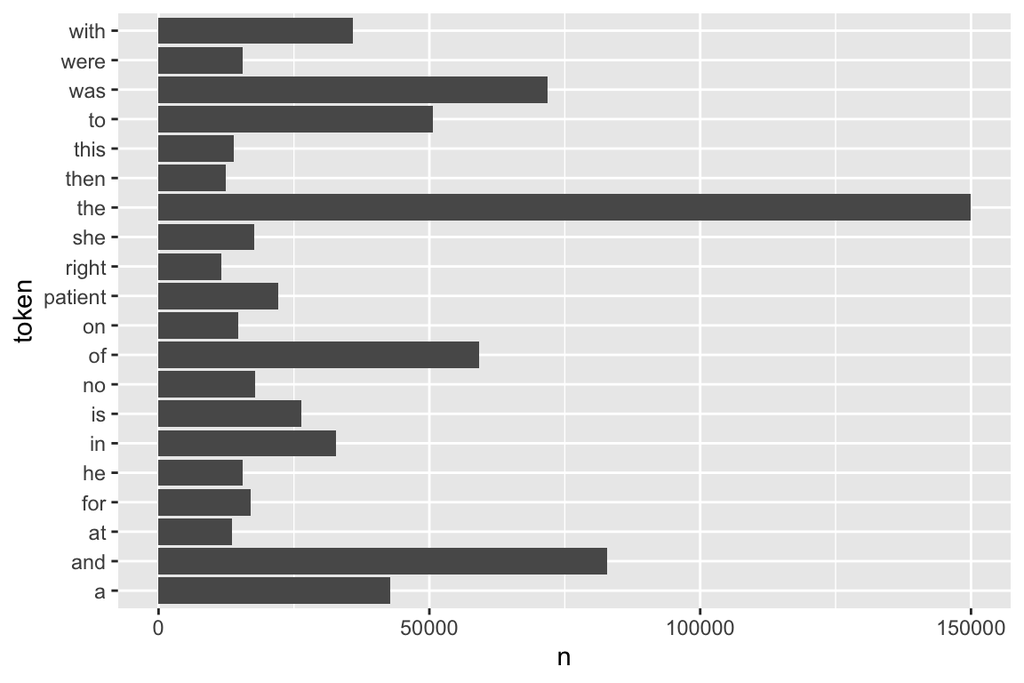

```r
tokenize %>%
  count(token)  %>%
  top_n(20, n)  %>%
  ggplot(aes(n, token)) +
  geom_col()
```

## Question 3

- Redo visualization but remove stopwords before
- Bonus points if you remove numbers as well

What do we see know that we have removed stop words? Does it give us a better idea of what the text is about?

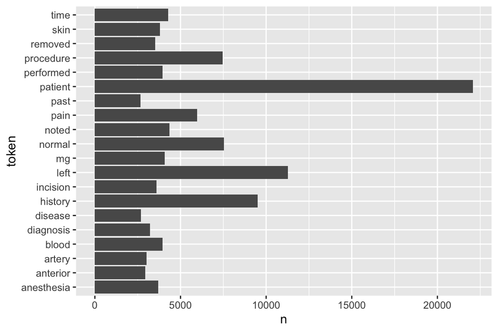

```r
important_words <- tokenize %>%
  anti_join(stop_words, by = c("token" = "word")) |>
  filter(!str_detect(token, "^[0-9]+$")) |>
  count(token, sort = TRUE)

plotq3 <- important_words %>%
  top_n(20, n)  %>%
  ggplot(aes(n, token)) +
  geom_col()

print(plotq3)
```

# Question 4

repeat question 2, but this time tokenize into bi-grams. how does the result change if you look at tri-grams?

```r
bi <- mt_samples %>%
  unnest_ngrams(ngram, transcription, n = 2)

bi %>%
  count(ngram, sort = TRUE)
```

```
# A tibble: 301,419 × 2
   ngram           n
   <chr>       <int>
 1 the patient 20307
 2 of the      19062
 3 in the      12790
 4 to the      12374
 5 was then     6956
 6 and the      6350
 7 patient was  6293
 8 the right    5509
 9 on the       5241
10 the left     4860
# ℹ 301,409 more rows
```

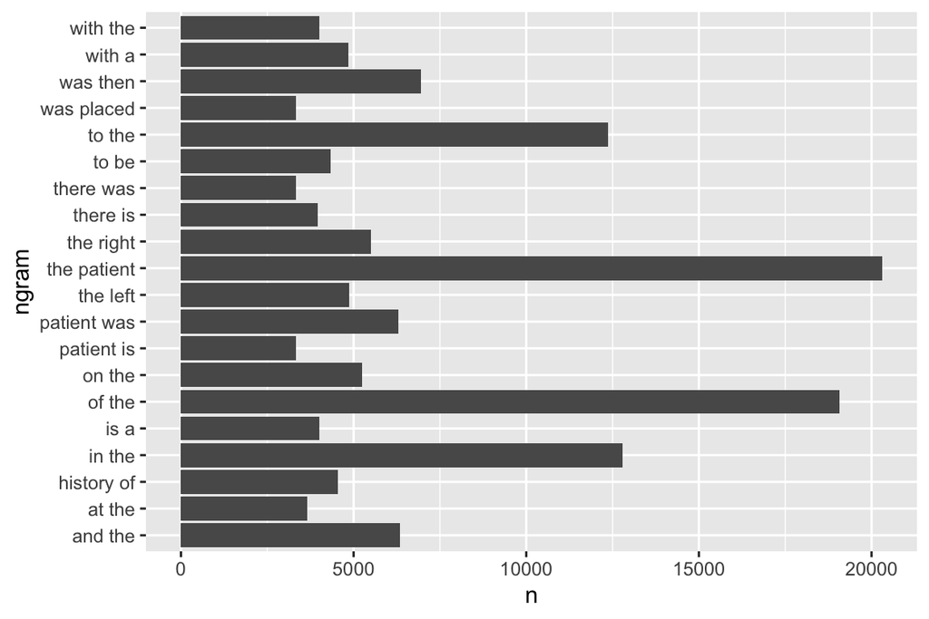

```r
plotbi <- bi %>%
  count(ngram)  %>%
  top_n(20, n)  %>%
  ggplot(aes(n, ngram)) +
  geom_col()

print(plotbi)
```

```r
tri <- mt_samples %>%
  unnest_ngrams(ngram, transcription, n = 3)

tri %>%
  count(ngram, sort = TRUE)
```

```
# A tibble: 655,442 × 2
   ngram                  n
   <chr>              <int>
 1 the patient was     6104
 2 the patient is      3075
 3 as well as          2243
 4 there is no         1678
 5 the operating room  1532
 6 patient is a        1491
 7 prepped and draped  1490
 8 was used to         1480
 9 and draped in       1372
10 at this time        1333
# ℹ 655,432 more rows
```

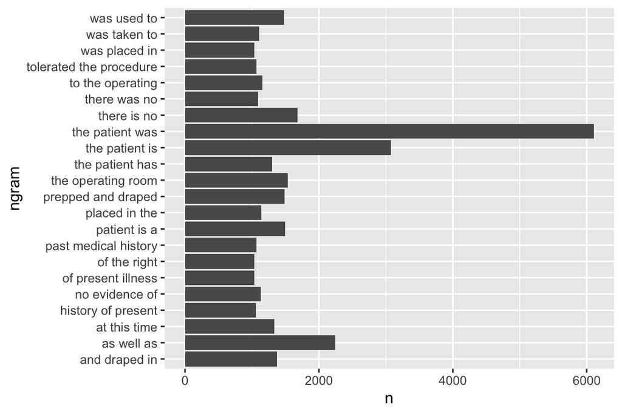

```r
plottri <- tri %>%
  count(ngram)  %>%
  top_n(20, n)  %>%
  ggplot(aes(n, ngram)) +
  geom_col()

print(plottri)
```

# Question 5

Using the results you got from questions 4. Pick a word and count the words that appears after and before it.

```r
after <- bi %>%
  separate(ngram, into = c("word1", "word2"), sep = " ") |>
  select(word1, word2) |>
  filter(word1 == "patient") |>
  count(word2, sort = TRUE)



before <- bi %>%
  separate(ngram, into = c("word1", "word2"), sep = " ") |>
  select(word1, word2) |>
  filter(word2 == "patient") |>
  count(word1, sort = TRUE)

head(after)
```

```
# A tibble: 6 × 2
  word2         n
  <chr>     <int>
1 was        6293
2 is         3332
3 has        1417
4 tolerated   994
5 had         888
6 will        616
```

```r
head(before)
```

```
# A tibble: 6 × 2
  word1         n
  <chr>     <int>
1 the       20307
2 this        470
3 history     101
4 a            67
5 and          47
6 procedure    32
```

# Question 6

Which words are most used in each of the specialties. you can use `group_by()` and `top_n()` from `dplyr` to have the calculations be done within each specialty. Remember to remove stopwords. How about the most 5 used words?

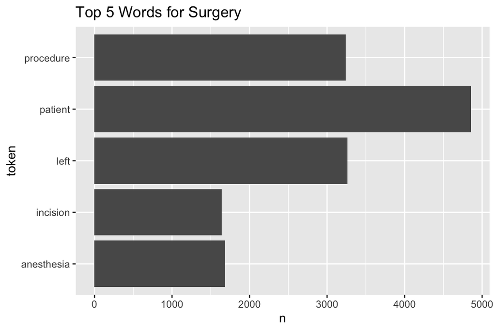

```r
important_words_spec <- tokenize %>%
  anti_join(stop_words, by = c("token" = "word")) |>
  group_by(medical_specialty) |>
  filter(!str_detect(token, "^[0-9]+$")) |>
  count(token, sort = TRUE)

plotq6 <- important_words_spec %>%
  filter(medical_specialty == "Surgery") %>%
  top_n(5, n) %>%
  ggplot(aes(n, token)) +
  geom_col() +
  labs(title = paste("Top 5 Words for Surgery"))

print(plotq6)
```

# Question 7 - extra

Find your own insight in the data:

Ideas:

- Interesting ngrams
- See if certain words are used more in some specialties then others

```r
idf <- mt_samples |>
  unnest_tokens(transcription, transcription) |>
  count(transcription, medical_specialty) |>
  bind_tf_idf(transcription, medical_specialty, n) |>
  arrange(desc(tf_idf))

head(idf)
```

```
# A tibble: 6 × 6
  transcription medical_specialty            n      tf   idf  tf_idf
  <chr>         <chr>                    <int>   <dbl> <dbl>   <dbl>
1 carbohydrate  Diets and Nutritions        37 0.00904 2.30  0.0208
2 reactivity    Lab Medicine - Pathology     7 0.00360 3.00  0.0108
3 calories      Diets and Nutritions        24 0.00586 1.61  0.00943
4 tumor         Lab Medicine - Pathology    35 0.0180  0.470 0.00847
5 meal          Diets and Nutritions        26 0.00635 1.29  0.00820
6 tooth         Dentistry                  108 0.00763 1.05  0.00801
```

```r
get_sentiments('bing')
```

```
# A tibble: 6,786 × 2
   word        sentiment
   <chr>       <chr>
 1 2-faces     negative
 2 abnormal    negative
 3 abolish     negative
 4 abominable  negative
 5 abominably  negative
 6 abominate   negative
 7 abomination negative
 8 abort       negative
 9 aborted     negative
10 aborts      negative
# ℹ 6,776 more rows
```

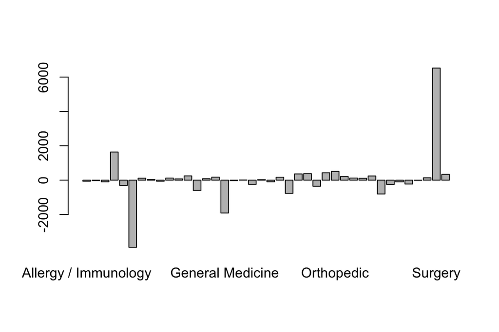

```r
bySpec <- mt_samples |>
  unnest_tokens(token, transcription) |>
  inner_join(get_sentiments("bing"), by = c("token" = "word")) |>
  group_by(medical_specialty) |>
  summarise(sentiment = sum(sentiment == "positive") - sum(sentiment == "negative"))

plotq7 <- barplot(bySpec$sentiment, names.arg = bySpec$medical_specialty)
```

```r
print(plotq7)
```

[output not shown]

[output cut: 26 more lines]